# Universidad Politecnica Salesiana

### Asignatura: Simulación.

# Covid-19 infección en Ecuador. Modelos probabilisticos

Implementacion de un modelo probabilistico de infección por el virus Covid-19

Se realiza un análisis probabilistico simple del crecimiento de la infección en Python y el modelos para comprender mejor la evolución de la infección.

Se crea modelos de series temporales del número total de personas infectadas hasta la fecha (es decir, las personas realmente infectadas más las personas que han sido infectadas). Estos modelos tienen parámetros , que se estimarán por ajuste de probabilidad.

```python
# Importar las librerias para el analasis
import pandas as pd
import numpy as np
from datetime import datetime,timedelta
from sklearn.metrics import mean_squared_error
from scipy.optimize import curve_fit
from scipy.optimize import fsolve
from sklearn import linear_model
import matplotlib.pyplot as plt
%matplotlib inline
```

```python
# Actualizar los datos (URL)
url = 'https://covid.ourworldindata.org/data/ecdc/new_cases.csv'
df = pd.read_csv(url)
df
```

|  | date | World | Afghanistan | Albania | Algeria | Andorra | Angola | Anguilla | Antigua and Barbuda | Argentina | ... | Uzbekistan | Vanuatu | Vatican | Venezuela | Vietnam | Wallis and Futuna | Western Sahara | Yemen | Zambia | Zimbabwe |
| --- | --- | --- | --- | --- | --- | --- | --- | --- | --- | --- | --- | --- | --- | --- | --- | --- | --- | --- | --- | --- | --- |
| 0 | 2019-12-31 | 27 | 0.0 | NaN | 0.0 | NaN | NaN | NaN | NaN | NaN | ... | NaN | NaN | NaN | NaN | 0.0 | NaN | NaN | NaN | NaN | NaN |
| 1 | 2020-01-01 | 0 | 0.0 | NaN | 0.0 | NaN | NaN | NaN | NaN | NaN | ... | NaN | NaN | NaN | NaN | 0.0 | NaN | NaN | NaN | NaN | NaN |
| 2 | 2020-01-02 | 0 | 0.0 | NaN | 0.0 | NaN | NaN | NaN | NaN | NaN | ... | NaN | NaN | NaN | NaN | 0.0 | NaN | NaN | NaN | NaN | NaN |
| 3 | 2020-01-03 | 17 | 0.0 | NaN | 0.0 | NaN | NaN | NaN | NaN | NaN | ... | NaN | NaN | NaN | NaN | 0.0 | NaN | NaN | NaN | NaN | NaN |
| 4 | 2020-01-04 | 0 | 0.0 | NaN | 0.0 | NaN | NaN | NaN | NaN | NaN | ... | NaN | NaN | NaN | NaN | 0.0 | NaN | NaN | NaN | NaN | NaN |
| 5 | 2020-01-05 | 15 | 0.0 | NaN | 0.0 | NaN | NaN | NaN | NaN | NaN | ... | NaN | NaN | NaN | NaN | 0.0 | NaN | NaN | NaN | NaN | NaN |
| 6 | 2020-01-06 | 0 | 0.0 | NaN | 0.0 | NaN | NaN | NaN | NaN | NaN | ... | NaN | NaN | NaN | NaN | 0.0 | NaN | NaN | NaN | NaN | NaN |
| 7 | 2020-01-07 | 0 | 0.0 | NaN | 0.0 | NaN | NaN | NaN | NaN | NaN | ... | NaN | NaN | NaN | NaN | 0.0 | NaN | NaN | NaN | NaN | NaN |
| 8 | 2020-01-08 | 0 | 0.0 | NaN | 0.0 | NaN | NaN | NaN | NaN | NaN | ... | NaN | NaN | NaN | NaN | 0.0 | NaN | NaN | NaN | NaN | NaN |
| 9 | 2020-01-09 | 0 | 0.0 | NaN | 0.0 | NaN | NaN | NaN | NaN | NaN | ... | NaN | NaN | NaN | NaN | 0.0 | NaN | NaN | NaN | NaN | NaN |
| 10 | 2020-01-10 | 0 | 0.0 | NaN | 0.0 | NaN | NaN | NaN | NaN | NaN | ... | NaN | NaN | NaN | NaN | 0.0 | NaN | NaN | NaN | NaN | NaN |
| 11 | 2020-01-11 | 0 | 0.0 | NaN | 0.0 | NaN | NaN | NaN | NaN | NaN | ... | NaN | NaN | NaN | NaN | 0.0 | NaN | NaN | NaN | NaN | NaN |
| 12 | 2020-01-12 | 0 | 0.0 | NaN | 0.0 | NaN | NaN | NaN | NaN | NaN | ... | NaN | NaN | NaN | NaN | 0.0 | NaN | NaN | NaN | NaN | NaN |
| 13 | 2020-01-13 | 1 | 0.0 | NaN | 0.0 | NaN | NaN | NaN | NaN | NaN | ... | NaN | NaN | NaN | NaN | 0.0 | NaN | NaN | NaN | NaN | NaN |
| 14 | 2020-01-14 | 1 | 0.0 | NaN | 0.0 | NaN | NaN | NaN | NaN | NaN | ... | NaN | NaN | NaN | NaN | 0.0 | NaN | NaN | NaN | NaN | NaN |
| 15 | 2020-01-15 | 1 | 0.0 | NaN | 0.0 | NaN | NaN | NaN | NaN | NaN | ... | NaN | NaN | NaN | NaN | 0.0 | NaN | NaN | NaN | NaN | NaN |
| 16 | 2020-01-16 | 0 | 0.0 | NaN | 0.0 | NaN | NaN | NaN | NaN | NaN | ... | NaN | NaN | NaN | NaN | 0.0 | NaN | NaN | NaN | NaN | NaN |
| 17 | 2020-01-17 | 5 | 0.0 | NaN | 0.0 | NaN | NaN | NaN | NaN | NaN | ... | NaN | NaN | NaN | NaN | 0.0 | NaN | NaN | NaN | NaN | NaN |
| 18 | 2020-01-18 | 17 | 0.0 | NaN | 0.0 | NaN | NaN | NaN | NaN | NaN | ... | NaN | NaN | NaN | NaN | 0.0 | NaN | NaN | NaN | NaN | NaN |
| 19 | 2020-01-19 | 136 | 0.0 | NaN | 0.0 | NaN | NaN | NaN | NaN | NaN | ... | NaN | NaN | NaN | NaN | 0.0 | NaN | NaN | NaN | NaN | NaN |
| 20 | 2020-01-20 | 20 | 0.0 | NaN | 0.0 | NaN | NaN | NaN | NaN | NaN | ... | NaN | NaN | NaN | NaN | 0.0 | NaN | NaN | NaN | NaN | NaN |
| 21 | 2020-01-21 | 153 | 0.0 | NaN | 0.0 | NaN | NaN | NaN | NaN | NaN | ... | NaN | NaN | NaN | NaN | 0.0 | NaN | NaN | NaN | NaN | NaN |
| 22 | 2020-01-22 | 142 | 0.0 | NaN | 0.0 | NaN | NaN | NaN | NaN | NaN | ... | NaN | NaN | NaN | NaN | 0.0 | NaN | NaN | NaN | NaN | NaN |
| 23 | 2020-01-23 | 97 | 0.0 | NaN | 0.0 | NaN | NaN | NaN | NaN | NaN | ... | NaN | NaN | NaN | NaN | 0.0 | NaN | NaN | NaN | NaN | NaN |
| 24 | 2020-01-24 | 266 | 0.0 | NaN | 0.0 | NaN | NaN | NaN | NaN | NaN | ... | NaN | NaN | NaN | NaN | 2.0 | NaN | NaN | NaN | NaN | NaN |
| 25 | 2020-01-25 | 453 | 0.0 | NaN | 0.0 | NaN | NaN | NaN | NaN | NaN | ... | NaN | NaN | NaN | NaN | 0.0 | NaN | NaN | NaN | NaN | NaN |
| 26 | 2020-01-26 | 673 | 0.0 | NaN | 0.0 | NaN | NaN | NaN | NaN | NaN | ... | NaN | NaN | NaN | NaN | 0.0 | NaN | NaN | NaN | NaN | NaN |
| 27 | 2020-01-27 | 797 | 0.0 | NaN | 0.0 | NaN | NaN | NaN | NaN | NaN | ... | NaN | NaN | NaN | NaN | 0.0 | NaN | NaN | NaN | NaN | NaN |
| 28 | 2020-01-28 | 1767 | 0.0 | NaN | 0.0 | NaN | NaN | NaN | NaN | NaN | ... | NaN | NaN | NaN | NaN | 0.0 | NaN | NaN | NaN | NaN | NaN |
| 29 | 2020-01-29 | 1480 | 0.0 | NaN | 0.0 | NaN | NaN | NaN | NaN | NaN | ... | NaN | NaN | NaN | NaN | 0.0 | NaN | NaN | NaN | NaN | NaN |
| ... | ... | ... | ... | ... | ... | ... | ... | ... | ... | ... | ... | ... | ... | ... | ... | ... | ... | ... | ... | ... | ... |
| 305 | 2020-10-31 | 542158 | 157.0 | 319.0 | 319.0 | 98.0 | 195.0 | 0.0 | 3.0 | 13955.0 | ... | 86.0 | NaN | 0.0 | 309.0 | 0.0 | 0.0 | 0.0 | 0.0 | 90.0 | 13.0 |
| 306 | 2020-11-01 | 457999 | 76.0 | 241.0 | 291.0 | 91.0 | 289.0 | 0.0 | 1.0 | 9745.0 | ... | 427.0 | NaN | 0.0 | 424.0 | 3.0 | 0.0 | 0.0 | 0.0 | 17.0 | 0.0 |
| 307 | 2020-11-02 | 487232 | 132.0 | 327.0 | 330.0 | 69.0 | 247.0 | 0.0 | 0.0 | 6609.0 | ... | 101.0 | NaN | 0.0 | 312.0 | 0.0 | 0.0 | 0.0 | 0.0 | 48.0 | 12.0 |
| 308 | 2020-11-03 | 470494 | 95.0 | 321.0 | 302.0 | 63.0 | 230.0 | 0.0 | 0.0 | 9598.0 | ... | 98.0 | NaN | 0.0 | 380.0 | 12.0 | 0.0 | 0.0 | 0.0 | 63.0 | 15.0 |
| 309 | 2020-11-04 | 504999 | 86.0 | 381.0 | 405.0 | 22.0 | 193.0 | 0.0 | 2.0 | 12145.0 | ... | 299.0 | NaN | 0.0 | 395.0 | 11.0 | 0.0 | 0.0 | 4.0 | 118.0 | 21.0 |
| 310 | 2020-11-05 | 569891 | 121.0 | 396.0 | 548.0 | 135.0 | 349.0 | 0.0 | 0.0 | 10652.0 | ... | 226.0 | NaN | 0.0 | 0.0 | 4.0 | 0.0 | 0.0 | 0.0 | 37.0 | 17.0 |
| 311 | 2020-11-06 | 612387 | 40.0 | 421.0 | 642.0 | 90.0 | 236.0 | 0.0 | 0.0 | 11100.0 | ... | 360.0 | NaN | 0.0 | 821.0 | 0.0 | 0.0 | 0.0 | 0.0 | 72.0 | 17.0 |
| 312 | 2020-11-07 | 606021 | 58.0 | 489.0 | 631.0 | 0.0 | 289.0 | 0.0 | 0.0 | 11786.0 | ... | 0.0 | NaN | 0.0 | 384.0 | 6.0 | 0.0 | 0.0 | 3.0 | 49.0 | 27.0 |
| 313 | 2020-11-08 | 593274 | 126.0 | 495.0 | 581.0 | 184.0 | 121.0 | 0.0 | 1.0 | 8037.0 | ... | 228.0 | NaN | 0.0 | 0.0 | 0.0 | 0.0 | 0.0 | 0.0 | 89.0 | 27.0 |
| 314 | 2020-11-09 | 528837 | 80.0 | 501.0 | 670.0 | 64.0 | 112.0 | 0.0 | 0.0 | 5331.0 | ... | 421.0 | NaN | 0.0 | 578.0 | 0.0 | 0.0 | 0.0 | 0.0 | 46.0 | 33.0 |
| 315 | 2020-11-10 | 502288 | 224.0 | 525.0 | 642.0 | 54.0 | 98.0 | 0.0 | 0.0 | 8317.0 | ... | 239.0 | NaN | 0.0 | 0.0 | 3.0 | 0.0 | 0.0 | 0.0 | 17.0 | 30.0 |
| 316 | 2020-11-11 | 566935 | 0.0 | 563.0 | 753.0 | 40.0 | 247.0 | 0.0 | 0.0 | 11976.0 | ... | 146.0 | 1.0 | 0.0 | 562.0 | 10.0 | 0.0 | 0.0 | 0.0 | 26.0 | 49.0 |
| 317 | 2020-11-12 | 623511 | 146.0 | 507.0 | 811.0 | 90.0 | 136.0 | 0.0 | 0.0 | 10880.0 | ... | 224.0 | 0.0 | 0.0 | 0.0 | 26.0 | 0.0 | 0.0 | 0.0 | 39.0 | 57.0 |
| 318 | 2020-11-13 | 647499 | 360.0 | 410.0 | 851.0 | 49.0 | 137.0 | 0.0 | 0.0 | 11162.0 | ... | 220.0 | 0.0 | 0.0 | 695.0 | 1.0 | 0.0 | 0.0 | 0.0 | 0.0 | 29.0 |
| 319 | 2020-11-14 | 635829 | 66.0 | 490.0 | 867.0 | 109.0 | 104.0 | 0.0 | 2.0 | 11859.0 | ... | 63.0 | 0.0 | 0.0 | 0.0 | 3.0 | 0.0 | 0.0 | 2.0 | 57.0 | 69.0 |
| 320 | 2020-11-15 | 594470 | 205.0 | 532.0 | 844.0 | 0.0 | 171.0 | 0.0 | 1.0 | 8468.0 | ... | 0.0 | 0.0 | 0.0 | 301.0 | 9.0 | 0.0 | 0.0 | 0.0 | 4.0 | 21.0 |
| 321 | 2020-11-16 | 514538 | 163.0 | 597.0 | 860.0 | 147.0 | 146.0 | 0.0 | 0.0 | 5645.0 | ... | 563.0 | 0.0 | 0.0 | 911.0 | 16.0 | 0.0 | 0.0 | 0.0 | 26.0 | 0.0 |
| 322 | 2020-11-17 | 544481 | 65.0 | 602.0 | 910.0 | 42.0 | 77.0 | 0.0 | 0.0 | 7895.0 | ... | 201.0 | 0.0 | 0.0 | 387.0 | 2.0 | 0.0 | 0.0 | 0.0 | 64.0 | 111.0 |
| 323 | 2020-11-18 | 582979 | 383.0 | 694.0 | 1002.0 | 37.0 | 164.0 | 0.0 | 0.0 | 10621.0 | ... | 204.0 | 0.0 | 0.0 | 311.0 | 5.0 | 0.0 | 0.0 | 0.0 | 56.0 | 48.0 |
| 324 | 2020-11-19 | 625770 | 0.0 | 711.0 | 1038.0 | 67.0 | 203.0 | 0.0 | 5.0 | 10332.0 | ... | 210.0 | 0.0 | 0.0 | 300.0 | 12.0 | 0.0 | 0.0 | 11.0 | 37.0 | 36.0 |
| 325 | 2020-11-20 | 640970 | 282.0 | 786.0 | 1023.0 | 48.0 | 104.0 | 0.0 | 0.0 | 10110.0 | ... | 213.0 | 0.0 | 0.0 | 315.0 | 4.0 | 1.0 | 0.0 | 3.0 | 70.0 | 65.0 |
| 326 | 2020-11-21 | 679758 | 232.0 | 836.0 | 1103.0 | 76.0 | 212.0 | 0.0 | 0.0 | 9592.0 | ... | 209.0 | 0.0 | 0.0 | 0.0 | 1.0 | 0.0 | 0.0 | 4.0 | 23.0 | 74.0 |
| 327 | 2020-11-22 | 572043 | 154.0 | 737.0 | 1019.0 | 65.0 | 279.0 | 0.0 | 0.0 | 7143.0 | ... | 0.0 | 0.0 | 0.0 | 352.0 | 1.0 | 0.0 | 0.0 | 3.0 | 21.0 | 52.0 |
| 328 | 2020-11-23 | 518858 | 252.0 | 565.0 | 1088.0 | 49.0 | 80.0 | 1.0 | 0.0 | 4181.0 | ... | 337.0 | 0.0 | 0.0 | 818.0 | 0.0 | 0.0 | 0.0 | 6.0 | 30.0 | 48.0 |
| 329 | 2020-11-24 | 533527 | 246.0 | 795.0 | 1005.0 | 48.0 | 0.0 | 0.0 | 0.0 | 3998.0 | ... | 230.0 | 0.0 | 0.0 | 308.0 | 6.0 | 0.0 | 0.0 | 8.0 | 30.0 | 88.0 |
| 330 | 2020-11-25 | 561704 | 185.0 | 744.0 | 1133.0 | 47.0 | 141.0 | 0.0 | 1.0 | 7434.0 | ... | 192.0 | 0.0 | 0.0 | 355.0 | 4.0 | 0.0 | 0.0 | 7.0 | 12.0 | 90.0 |
| 331 | 2020-11-26 | 649666 | 200.0 | 644.0 | 1025.0 | 77.0 | 108.0 | 0.0 | 0.0 | 8593.0 | ... | 188.0 | 0.0 | 0.0 | 319.0 | 5.0 | 1.0 | 0.0 | 10.0 | 69.0 | 110.0 |
| 332 | 2020-11-27 | 549900 | 0.0 | 656.0 | 1085.0 | 106.0 | 79.0 | 0.0 | 1.0 | 9043.0 | ... | 182.0 | 0.0 | 0.0 | 0.0 | 10.0 | 0.0 | 0.0 | 13.0 | 18.0 | 115.0 |
| 333 | 2020-11-28 | 616139 | 214.0 | 645.0 | NaN | 76.0 | NaN | 0.0 | 0.0 | 7846.0 | ... | 0.0 | 0.0 | 0.0 | 398.0 | 8.0 | 0.0 | 0.0 | 11.0 | 16.0 | 91.0 |
| 334 | 2020-11-29 | 552296 | 228.0 | 545.0 | 2102.0 | 60.0 | 266.0 | 0.0 | 0.0 | 6098.0 | ... | 0.0 | 0.0 | 0.0 | 309.0 | 2.0 | 0.0 | 0.0 | 12.0 | 20.0 | 108.0 |

335 rows × 216 columns

Imprimos los resultados y agregamos el numero del dia

```python
df = df.loc[:,['date','Ecuador']] #Selecciono las columnas de analasis
# Expresar las fechas en numero de dias desde el 01 Enero
FMT = '%Y-%m-%d'
date = df['date']
df['date'] = date.map(lambda x : (datetime.strptime(x, FMT) - datetime.strptime("2020-01-01", FMT)).days)
df
```

|  | date | Ecuador |
| --- | --- | --- |
| 0 | -1 | 0.0 |
| 1 | 0 | 0.0 |
| 2 | 1 | 0.0 |
| 3 | 2 | 0.0 |
| 4 | 3 | 0.0 |
| 5 | 4 | 0.0 |
| 6 | 5 | 0.0 |
| 7 | 6 | 0.0 |
| 8 | 7 | 0.0 |
| 9 | 8 | 0.0 |
| 10 | 9 | 0.0 |
| 11 | 10 | 0.0 |
| 12 | 11 | 0.0 |
| 13 | 12 | 0.0 |
| 14 | 13 | 0.0 |
| 15 | 14 | 0.0 |
| 16 | 15 | 0.0 |
| 17 | 16 | 0.0 |
| 18 | 17 | 0.0 |
| 19 | 18 | 0.0 |
| 20 | 19 | 0.0 |
| 21 | 20 | 0.0 |
| 22 | 21 | 0.0 |
| 23 | 22 | 0.0 |
| 24 | 23 | 0.0 |
| 25 | 24 | 0.0 |
| 26 | 25 | 0.0 |
| 27 | 26 | 0.0 |
| 28 | 27 | 0.0 |
| 29 | 28 | 0.0 |
| ... | ... | ... |
| 305 | 304 | 845.0 |
| 306 | 305 | 1045.0 |
| 307 | 306 | 1002.0 |
| 308 | 307 | 368.0 |
| 309 | 308 | 548.0 |
| 310 | 309 | 1323.0 |
| 311 | 310 | 350.0 |
| 312 | 311 | 725.0 |
| 313 | 312 | 978.0 |
| 314 | 313 | 1421.0 |
| 315 | 314 | 362.0 |
| 316 | 315 | 442.0 |
| 317 | 316 | 919.0 |
| 318 | 317 | 883.0 |
| 319 | 318 | 1161.0 |
| 320 | 319 | 953.0 |
| 321 | 320 | 668.0 |
| 322 | 321 | 381.0 |
| 323 | 322 | 428.0 |
| 324 | 323 | 1146.0 |
| 325 | 324 | 996.0 |
| 326 | 325 | 594.0 |
| 327 | 326 | 1036.0 |
| 328 | 327 | 767.0 |
| 329 | 328 | 301.0 |
| 330 | 329 | 492.0 |
| 331 | 330 | 794.0 |
| 332 | 331 | 908.0 |
| 333 | 332 | 1396.0 |
| 334 | 333 | 1375.0 |

335 rows × 2 columns

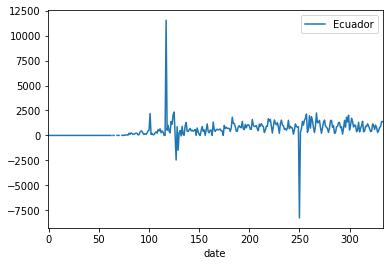

```python
df.plot(x ='date', y='Ecuador')
```

Ahora podemos analizar un modelo probabilisto para el examen.

## El modelo basado en probabilidad

Para realizar un estimacion del factor de crecimiento de los casos de Covid 19 en Ecuador calculamos la mediana, con esto obtenemo el valor medio de crecimiento de un conjunto de datos, con esto podemos obtener un factor de crecimiento o taza de crecimiento de los nuevos casos.

```python
filtro = df["Ecuador"][61:] # Filtro los datos que se empezo a tener casos
#Obtenemos la mediana
media = filtro.mean()
mediana = filtro.median()
print("La mediana es: ", mediana)
print("La media es:", media)
```

```
La mediana es:  670.0
La media es: 709.6988847583643
```

De la ecuación de la recta y = mX + b nuestra pendiente «m» es el coeficiente y el término independiente «b»

```python
#Vamos a comprobar:
# según la media y la mediana podemos obtener la taza de crecieminto y predicir su comportamiento.
# Cargamos los datos de total de casos
url = 'https://covid.ourworldindata.org/data/ecdc/total_cases.csv'
df_t = pd.read_csv(url)
FMT = '%Y-%m-%d'
date = df_t['date']
df_t['date'] = date.map(lambda x : (datetime.strptime(x, FMT) - datetime.strptime("2020-01-01", FMT)).days)
df_t = df_t.loc[:,['date','Ecuador']] #Selecciono las columnas de analasis
y = list(df_t.iloc [:, 1]) # Total casos
x = list(df_t.iloc [:, 0]) # Dias
#Realizamos un ejemplo de prediccion
prediccion_siguiente = int(y[-1] + mediana)
print(prediccion_siguiente)
```

```
191579
```

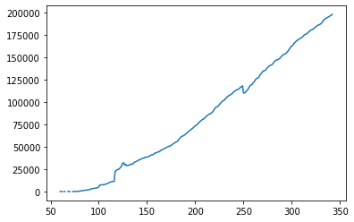

```python
# Quiero predecir cuántos "Casos" voy a obtener de aqui a 10 dias.
for i in range(x[-1], x[-1]+10):
    x.append(i)
    y.append(int(y[-1] + mediana))
valorProbabilistico=y[319]
plt.plot(x[61:], y[61:])
plt.show()
```

# Practica

1. Comparar el modelo de predicion matematico vs probabilidad.
2. Generar el SIR en base al modelo de probabilidad y obtener beta y gamma con una semana de prediccion.
3. Retroceder un semana y comparar el modelo matematico vs probabilidad vs reales. Solo cargan los datos para generar los modelos menos 7 dias.

Puntos extras: Investigas sobre la correlacion de variables y aplicar el calculo en base a los datos del Ecuador.

## 1. Comparar el modelo de predicion matematico vs probabilidad

### Modelo Probabilistico

```
Los casos en los proximos días serán:  202306
```

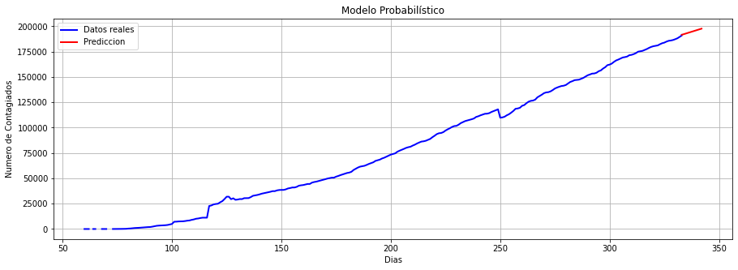

```python
# Implementar
fig = plt.figure(figsize=(15,5))
ax = fig.add_subplot(111, axisbelow=True)
ax.plot(x[:len(x)-9], y[:len(x)-9],'b', alpha=1, lw = 2, label = 'Datos reales')
ax.plot(x[len(x)-10:], y[len(x)-10:],'r', alpha=1, lw = 2, label = 'Prediccion')
ax.set_xlabel('Dias')
ax.set_ylabel('Numero de Contagiados')
ax.set_title("Modelo Probabilístico")
ax.legend()
ax.grid()
x_matematico = x[:]
y_matematico = y[:]

for i in range(x[-1], x[-1]+7):
    x.append(i)
    y.append(int(y[-1] + mediana))
print('Los casos en los proximos días serán: ',y[-1]+7,)
```

### Modelo Polinomial

```
Los casos en los próximos 7 días serán:  151420.4857
```

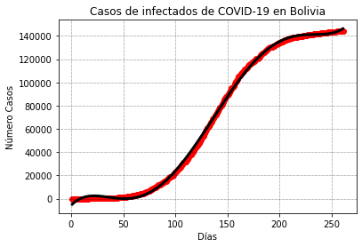

```python
#Implementar
df = pd.read_csv('owid-covid-data.csv').fillna(0)
ndf= df.loc[(df['location'] == 'Bolivia') & (df['total_cases'] != 0)]
ndf1=ndf[['date','total_cases']]
x=np.arange(1,len(ndf1)+1,1, dtype='float')
y=np.array(ndf1.values[:,1], dtype='float')
fun_pol = np.poly1d(np.polyfit(x, y, 5))
# print(fun_pol)
# print()
print('Los casos en los próximos 7 días serán: ', round(fun_pol(len(x)+7),5))
y_pred=fun_pol(x)

#Propiedades
plt.title('Casos de infectados de COVID-19 en Bolivia')
plt.xlabel('Días')
plt.ylabel('Número Casos')
plt.grid(color='black', linestyle='dotted', linewidth=0.5)

plt.scatter(x,y,label="Casos de Datos Reales",color="red")
plt.plot(x, y_pred, c='black',lw=3)
plt.show()
```

### Modelo Probabilistico

```
Los casos en la semana pasada fueron:  202292
```

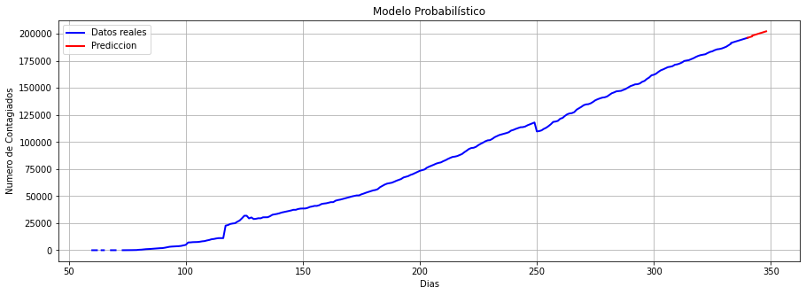

```python
# Implementar
fig = plt.figure(figsize=(15,5))
ax = fig.add_subplot(111, axisbelow=True)
ax.plot(x[:len(x)-9], y[:len(x)-9],'b', alpha=1, lw = 2, label = 'Datos reales')
ax.plot(x[len(x)-10:], y[len(x)-10:],'r', alpha=1, lw = 2, label = 'Prediccion')
ax.set_xlabel('Dias')
ax.set_ylabel('Numero de Contagiados')
ax.set_title("Modelo Probabilístico")
ax.legend()
ax.grid()
x_matematico = x[:]
y_matematico = y[:]

for i in range(x[-1], x[-1]-7):
    x.append(i)
    y.append(int(y[-1] + mediana))
print('Los casos en la semana pasada fueron: ',y[-1]-7,)
```

### Modelo Polinomial

```
Los casos en la semana pasada fueron:  143378.67185
```

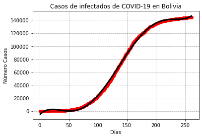

```python
#Implementar
df = pd.read_csv('owid-covid-data.csv').fillna(0)
ndf= df.loc[(df['location'] == 'Bolivia') & (df['total_cases'] != 0)]
ndf1=ndf[['date','total_cases']]
x=np.arange(1,len(ndf1)+1,1, dtype='float')
y=np.array(ndf1.values[:,1], dtype='float')
fun_pol = np.poly1d(np.polyfit(x, y, 5))
# print(fun_pol)
# print()
print('Los casos en la semana pasada fueron: ', round(fun_pol(len(x)-7),5))
y_pred=fun_pol(x)

#Propiedades
plt.title('Casos de infectados de COVID-19 en Bolivia')
plt.xlabel('Días')
plt.ylabel('Número Casos')
plt.grid(color='black', linestyle='dotted', linewidth=0.5)

plt.scatter(x,y,label="Casos de Datos Reales",color="red")
plt.plot(x, y_pred, c='black',lw=3)
plt.show()
```

## Conclusiones

Como conclusión tenemos que los modelos matematicos y probabilistico nos ayuda a predecir el futuro en este caso sobre la pandemia del covid-19, este modelo es subjetivo por lo que no siempre acertara con veracidad lo que sucederá a futuro, pero si nos dará una idea de lo que sucederá y de esta manera las personas puedan tomar consciencia y prevenir el virus.

## Criterio personal (politico, economico y social de la situacion)

En el ámbito político las autoridades de nuestro país deben regir medidas de seguridad, de salud y realizar planificaciones que ayuden al bienestar de la sociedad para de esa manera reducir el contagio y evitar mas muertes, en el ámbito económico esta pandemia a afectado a muchos negocios que algunos tuvieron que cerrar, existe una tasa alta de desempleo por lo que las personas ya no tienen dinero y puede ocasionar enfermedades como la desnutricióny otras, pero también existen personas que han emprendido un negocio vendiendo objetos mediante redes sociales, y en el ámbito social puedo decir que esta pandemia a afectado a todas las personas de nuestro país como al mundo entero, tanto en la salud, ingresos y empleo.

# Referencias

- https://www.researchgate.net/publication/340092755_Infeccion_del_Covid-19_en_Colombia_Una_comparacion_de_modelos_logisticos_y_exponenciales_aplicados_a_la_infeccion_por_el_virus_en_Colombia
- https://www.aprendemachinelearning.com/regresion-lineal-en-espanol-con-python/